# Interpretating Price Elasticity of Demand and Consumer and Producer Surplus

October 05, 2018

## Pregame

- Writing Assignment 2 (**Due 10/10**): Submit via blackboard
- Mean exam score: 61%. This is 10 percentage points higher than for other ECONS101 classes!

## Price elasticity of demand

- **Price Elasticity of Demand** - *The change in quantity demanded that results from a change in price.*

\[\varepsilon = \frac{\Delta Q / Q}{\Delta P / P}.\]

## Two extremes of price elasticity of demand

- Price elasticity of demand is zero: Change in quantity demanded for a (any) change in price is zero.
- Price elasticity of demand is infinite: Change in quantity demanded for a (any) change in price is infinite.

## Zero elasticity

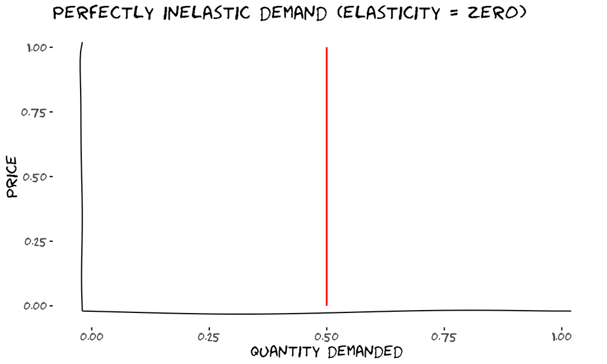

## Infinite elasticity

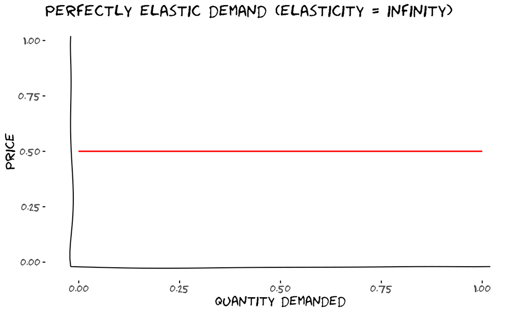

## Surplus

**Consumer Surplus** - *The difference between what a buyer would have been willing to pay and the price they pay.*

**Producer Surplus** - *The difference between the price the good is sold for and the seller’s cost to produce.*

## Surplus

[video not shown]

## Surplus

- **What is Edward’s surplus?**
- Willingness to pay (WTP) - Price = 4000 - 3000 = 1000.
- **What is Vivian’s surplus?**
- Price - Willingness to sell (or just cost) = 3000 - 2000 = 1000.

## Consumer and producer surplus

- See in class notes or module for more depth as well as discussion of Yakima Basin Irrigation Project.

## Wrapping Up

- Complete the [knowledge check](https://goo.gl/forms/bVuvvNN94gZktiz13) for today’s participation point.
- Please provide [feedback](https://goo.gl/forms/8SiOwdi19kN8cINJ3) on today’s lecture.